# IODS course project

Johanna Troberg

# About the project

The introduction to open data science course (IODS) will give us students an opportunity to get familiar with **R** programming language and some open software tools (**Rstudio**, **R markdown** and **Github**). Then later during the course, we will learn how these tools can be used in *statistical data analysis*.

[Johanna’s github repository](https://github.com/jtroberg/IODS-project/)

# Week 1

The R programming code and the tools we are using during this course are all new to me. I have little background in statistics, but I took those courses long time ago, so I don’t remember much about that topic either. In addition, I am a new mac user with very limited computer handling skills, so during this first week I have had some extra work trying to solve beginner’s issues such as how to download and install programs etc. Luckily there was a good amount of instructions available in the IODS-course page, including videos, so everything should be now installed and working, at least I hope so.

- The first week’s first assignment was to learn the very basics about the R programming language by using the **DataCamp** platform and passing the R introduction course: *R short and sweet*. This DataCamp course was actually straightforward and easy to pass if one was reading instructions carefully. Passing this took me quite a long time (because everything was so new to me, I had to read instructions more than once), but I had such fun studying through this short course, that I felt little sad as it ended after two chapters.
- The other assignment for the week was to learn to use **Rstudio** and **Github** programs, by writing and modifying the output of this diary page. To do that I had to download my “forked” version of the course datafile and open them with my local GitHub program. After that I was able to modify the files in the Rstudio and comment the changes through the GitHub.

# Week 2

In this week’s R exercise we are making the regression analysis from the questionare data about students’ learning methods (deep and surface learning) and attitudes toward the learning progress and study subject. The answers are scaled and combined together with final exam points, overall attitudes toward statistics, gender and age.

Before the analysis, we did data wrangling step (where the data table is converted into different type of file for analysis), and in this step the data was already filtered so that those answers that got 0 points are left out from the data table, the deep, strategic and learning question points were averiged and the attitude points were divided by the number of questions (about attitude).

**Tables 1-3. Data tables about summary of data and its structure.** Data table has seven different variables. The first variable is gender, which can be either female or male. The next one is age, and has integer value, as well as the exam points in the table. Other points in the table are averiged values from the multiple questions from that spesific topic.

```r
# Reading the data into R (students2014) from the  local data wrangling file (learning2014.txt). Setting the header=TRUE because file contains the names of the variables as its first line.

students2014<-read.table("~/Tiedostot_J/IODS-project/data/learning2014.txt", header=TRUE)

#Analysis of the data (structure and summary)


str(students2014)
```

```
## 'data.frame':    166 obs. of  7 variables:
##  $ gender  : Factor w/ 2 levels "F","M": 1 2 1 2 2 1 2 1 2 1 ...
##  $ age     : int  53 55 49 53 49 38 50 37 37 42 ...
##  $ attitude: int  37 31 25 35 37 38 35 29 38 21 ...
##  $ deep    : num  3.58 2.92 3.5 3.5 3.67 ...
##  $ stra    : num  3.38 2.75 3.62 3.12 3.62 ...
##  $ surf    : num  2.58 3.17 2.25 2.25 2.83 ...
##  $ points  : int  25 12 24 10 22 21 21 31 24 26 ...
```

```r
head(students2014)
```

```
##   gender age attitude     deep  stra     surf points
## 1      F  53       37 3.583333 3.375 2.583333     25
## 2      M  55       31 2.916667 2.750 3.166667     12
## 3      F  49       25 3.500000 3.625 2.250000     24
## 4      M  53       35 3.500000 3.125 2.250000     10
## 5      M  49       37 3.666667 3.625 2.833333     22
## 6      F  38       38 4.750000 3.625 2.416667     21
```

```r
summary(students2014)
```

```
##  gender       age           attitude          deep            stra
##  F:110   Min.   :17.00   Min.   :14.00   Min.   :1.583   Min.   :1.250
##  M: 56   1st Qu.:21.00   1st Qu.:26.00   1st Qu.:3.333   1st Qu.:2.625
##          Median :22.00   Median :32.00   Median :3.667   Median :3.188
##          Mean   :25.51   Mean   :31.43   Mean   :3.680   Mean   :3.121
##          3rd Qu.:27.00   3rd Qu.:37.00   3rd Qu.:4.083   3rd Qu.:3.625
##          Max.   :55.00   Max.   :50.00   Max.   :4.917   Max.   :5.000
##       surf           points
##  Min.   :1.583   Min.   : 7.00
##  1st Qu.:2.417   1st Qu.:19.00
##  Median :2.833   Median :23.00
##  Mean   :2.787   Mean   :22.72
##  3rd Qu.:3.167   3rd Qu.:27.75
##  Max.   :4.333   Max.   :33.00
```

**Plot 1.** To summarize we have made a plot for attitude vs exam points. These results are divided on two colours based on the gender and lastly regression line is drawn to the plot to visualize if there is a gender difference.

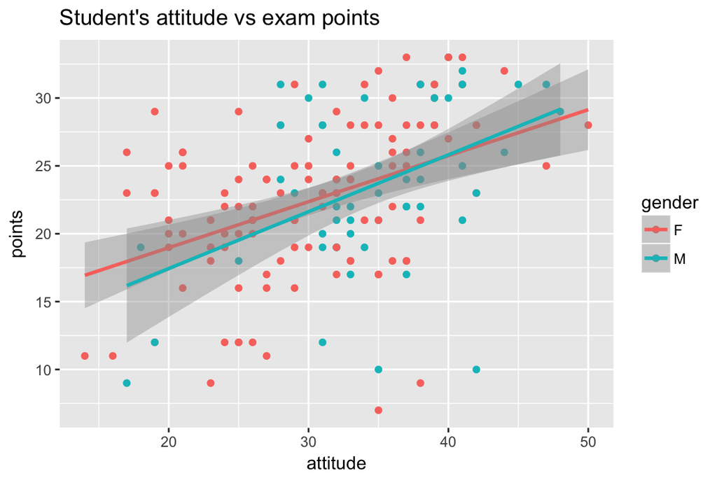

```r
#Accessing libraries ggplot2 and GGally
library(ggplot2)
library(GGally)

#  Plot with ggplot (aes)
p1 <- ggplot(students2014, aes(x = attitude, y = points, col = gender))

#  point visualization
p2 <- p1 + geom_point()

# adding a regression line
p3 <- p2 + geom_smooth(method = "lm")

# adding a title and drawing the plot
p4 <- p3 + ggtitle("Student's attitude vs exam points")

# printing the plot
p4
```

**Plot 2.** Plot about the summaries of the variables in the data. In this plot there is easily seen the different relationships between the variables.

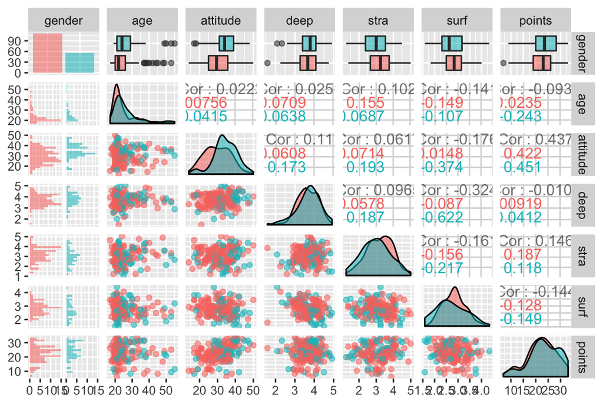

```r
# Drawing plot matrix with ggpairs()
p <- ggpairs(students2014, mapping = aes(col=gender, alpha=2), lower = list(combo = wrap("facethist", bins = 20)))


# draw the plot
p
```

**Table 4.** In this table, there is actual linear regression model for multiple variables used. The exam points are the target of the analysis and it gives the model to us as well as the details about the residuals in the model. From coefficients we can see where it crosses the Y-axis (points, intercept) and the model also estimates for each variable, if it is significant from zero. In other words, does that variable make a difference to the points (P and t values). The attitude seems to have the highest impact to exam points between these three variables.

The multiple R squared of the model tells us how well this data fits into multiple linear regression model. It determines how well the residuals fit the theoretical model values. More we have outliers from the model, the lower we have R squared value of the model telling us that some other model would be needed to explain our data. In our case, it seems that there is quite a lot variability of the data, meaning that it is not that strong dependence on the exam points and between attitude, age and strategic learning.

```r
# creating a regression model with multiple explanatory variables
my_model <- lm(points ~ attitude + age + stra, data = students2014)

# print out a summary of the model
summary(my_model)
```

```
##
## Call:
## lm(formula = points ~ attitude + age + stra, data = students2014)
##
## Residuals:
##      Min       1Q   Median       3Q      Max
## -18.1149  -3.2003   0.3303   3.4129  10.7599
##
## Coefficients:
##             Estimate Std. Error t value Pr(>|t|)
## (Intercept) 10.89543    2.64834   4.114 6.17e-05 ***
## attitude     0.34808    0.05622   6.191 4.72e-09 ***
## age         -0.08822    0.05302  -1.664   0.0981 .
## stra         1.00371    0.53434   1.878   0.0621 .
## ---
## Signif. codes:  0 '***' 0.001 '**' 0.01 '*' 0.05 '.' 0.1 ' ' 1
##
## Residual standard error: 5.26 on 162 degrees of freedom
## Multiple R-squared:  0.2182, Adjusted R-squared:  0.2037
## F-statistic: 15.07 on 3 and 162 DF,  p-value: 1.07e-08
```

**Plot 3.** Analysis of these diagnostic plots shows in the first plot again how well the residuals are corresponding the model fitted values. It should be scattered and not showing any kind of trend in this plot. The second plot is about normal QQ which is normality of errors. It should show no trend again going on some direction from the trendline. The third plot is about the leverage and residuals, and it takes into account that some residuals might have a larger effect on a model fitting than other. For example, large values might have larger effect than smaller ones when regression curve is fitted.

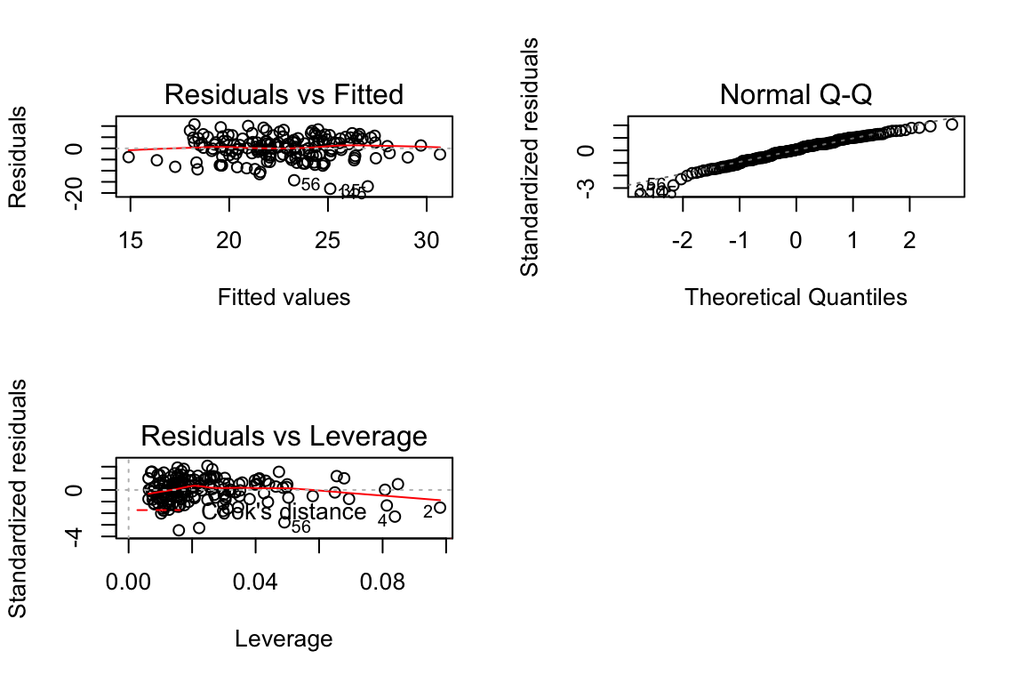

```r
# drawing diagnostic plots with plot(). Choosing the plots 1, 2 and 5. Par to show multiple plots at the same time (room for four plots, only 3 used here)
par(mfrow=c(2,2))
plot(my_model, which=c(1:2,5))
```

# Week 3

The data for this week’s analysis is from the UCI Machine Learning Repository: [link to the data source](https://archive.ics.uci.edu/ml/datasets/STUDENT+ALCOHOL+CONSUMPTION).

The data has 33 different variables (questions). Many variables are binary values, such as school, which is answered by the student either as GP (Gabriel Pereira) or MS (Mousinho da Silveira). Also family size is binary: LE3 is less or equal to 3, GT3 is greater than 3. Some binary variables are just answered either yes or no. There are some other variables that are answered by number, such as age that is answered by integer, number from 15-22. Also some questions are answered nominally, such as mother’s job. In the end there is G1, G2 and G3, which are the numeric grades from periods 1, 2 and the final grade from student’s course subject, Math or Portuguese. There are many background questions and questions related to studying, but also questions about alcohol consumption during the workdays and weekends.

The largest difference from the original data and the data table presented here (Table 1) is the two extra columns we have added here after grade variables, which are about alcohol use and high use of alcohol. The alcohol use combines the two original questions Dalc (workday alcohol consumption) and Walc (weekend alcohol consumption), which were estimated in numbers from 1-5, 1 being low use and 5 high, and gives an average of those. The high use is true for students whose combined alcohol use was more than 2. So in our data table we have 35 variables instead of 33 original ones. Also the data has been modified in the data wrangling the two different questionnaires have been merged to one, combining the data files and excluding the possible duplicate answers if one student has taken both questionnaires.

**Table 1.** Variables in the combined data file.

```r
alc<-read.table("~/Tiedostot_J/IODS-project/data/alc.txt", sep="", header=TRUE)

colnames(alc)
```

```
##  [1] "school"     "sex"        "age"        "address"    "famsize"
##  [6] "Pstatus"    "Medu"       "Fedu"       "Mjob"       "Fjob"
## [11] "reason"     "nursery"    "internet"   "guardian"   "traveltime"
## [16] "studytime"  "failures"   "schoolsup"  "famsup"     "paid"
## [21] "activities" "higher"     "romantic"   "famrel"     "freetime"
## [26] "goout"      "Dalc"       "Walc"       "health"     "absences"
## [31] "G1"         "G2"         "G3"         "alc_use"    "high_use"
```

The purpose of our analysis is to study relationships between some variables in the data set and alcohol consumption. For this purpose, I have chosen four variables that could have been effected by how much student is using alcohol in his/her life. Two variables are likely to be positively affected by low alcohol consumption and values of two variables should increase if the student consumes more alcohol. The low alcohol consumption could possible increase the quality of family relationships and weekly study time. The high alcohol consumption could have an effect on amounts of absences in school and going out more often with friends. So, I have chosen the following four variables for further analysis:

- Quality of family relationships (“famrel”, from 1 - very bad to 5 - excellent)
- Weekly study time (“studytime”, 1 - <2 hours, 2 - 2 to 5 hours, 3 - 5 to 10 hours, or 4 - >10 hours)
- Going out with friends (“goout”, from 1 - very low to 5 - very high)
- Number of school absences (“absences”, from 0 to 93)

These variables will be analyzed with high usage of alcohol, so the first graph should show low relationship with family when students are using high amounts of alcohol (TRUE in the graph), another should be also lower than for the students not using high amounts of alcohol (FALSE). In the two last figures it should be other way around, for high alcohol consumption the box should be higher than for low alcohol consumers.

In the **data table 1** there is the number of those students who are consuming higher amounts of alcohol (high alcohol consumption = TRUE) and those who are consuming less (high alcohol consumption = FALSE). In the **data table 2** there are the mean values of family relationships in the high alcohol consuming group (TRUE) and less alcohol consuming group (FALSE).

**Boxplot 1.** An effect of student’s alcohol consumption on family relationships.

```r
#access to libraries tidyr, dplyr and ggplot2. Had to suppress dplyr startupmessage.
suppressPackageStartupMessages({
library("dplyr")
})
library(dplyr)
library(tidyr)
library(ggplot2)

# produce summary statistics by group. How many from students are in the high alcohol consumption group?
alc %>% group_by(high_use) %>% summarise(count = n())
```

```
## # A tibble: 2 × 2
##   high_use count
##      <lgl> <int>
## 1    FALSE   268
## 2     TRUE   114
```

```r
# What is the mean value of family relationship values in low consumer's group?
alc %>% group_by(high_use) %>% summarise(mean_grade=mean(famrel))
```

```
## # A tibble: 2 × 2
##   high_use mean_grade
##      <lgl>      <dbl>
## 1    FALSE   4.003731
## 2     TRUE   3.780702
```

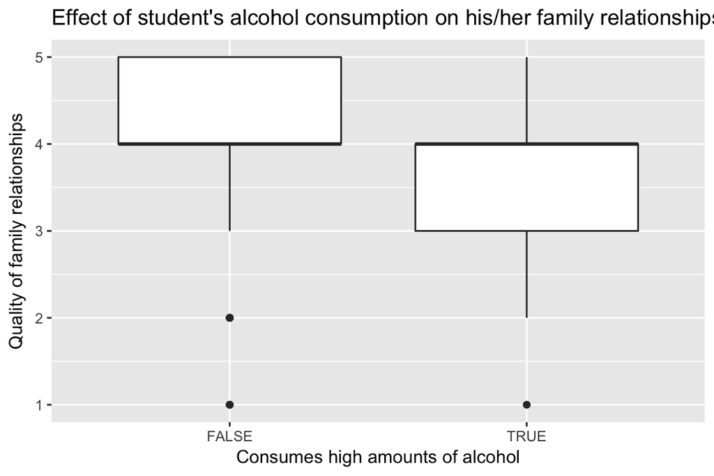

```r
# initialize a box plot of high_use and famrel, studytime, goout and absences.
g1<-ggplot(alc, aes(x=high_use, y=famrel))

# define the plot as a boxplot and draw it
g1 + geom_boxplot() + ylab("Quality of family relationships")+xlab("Consumes high amounts of alcohol")+ggtitle("Effect of student's alcohol consumption on his/her family relationships")
```

So it seems that the alcohol consumption possibly very small effect on quality of the family relationships. For those who did not use high amounts of alcohol estimated their family relationships to 4.0 (average) and those who used high amounts, the average value was 3.8.

In the **data table 3** there are the mean values of the time the students are using in the high alcohol consuming group (TRUE) and less alcohol consuming group (FALSE).

**Boxplot 2.** An effect of student’s alcohol consumption on time used studying.

```r
#access to libraries tidyr, dplyr and ggplot2.
library(tidyr); library(dplyr); library(ggplot2)

# What is the mean time used for studies in high/low consumer's group?
alc %>% group_by(high_use) %>% summarise(mean_grade=mean(studytime))
```

```
## # A tibble: 2 × 2
##   high_use mean_grade
##      <lgl>      <dbl>
## 1    FALSE   2.149254
## 2     TRUE   1.771930
```

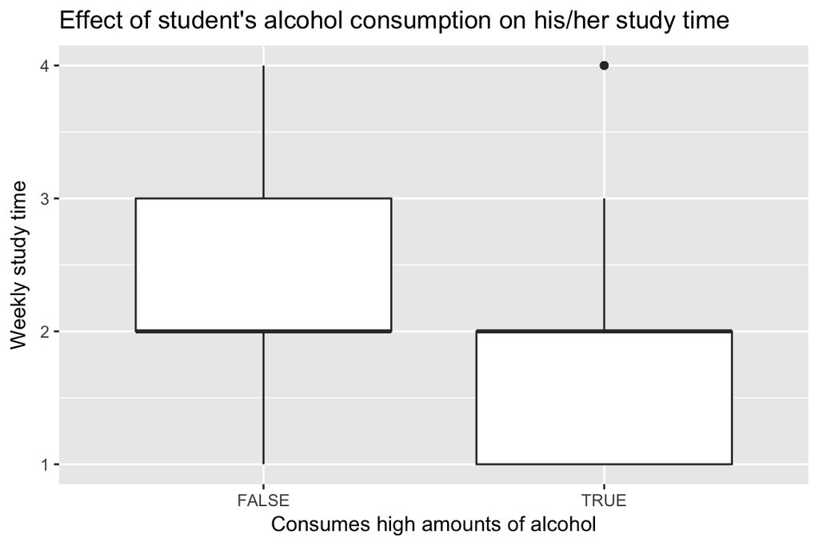

```r
g2<-ggplot(alc, aes(x=high_use, y=studytime))
g2 + geom_boxplot() + ylab("Weekly study time")+xlab("Consumes high amounts of alcohol")+ggtitle("Effect of student's alcohol consumption on his/her study time")
```

In the **data table 4** there are the mean values of the time the students are spending out with their friends in the high alcohol consuming group (TRUE) and less alcohol consuming group (FALSE).

**Boxplot 3.** An effect of student’s alcohol consumption on time spended out with their friends.

```r
#access to libraries tidyr, dplyr and ggplot2.
library(tidyr); library(dplyr); library(ggplot2)

# What is the going out with friends in high/low consumer's group?
alc %>% group_by(high_use) %>% summarise(mean_grade=mean(goout))
```

```
## # A tibble: 2 × 2
##   high_use mean_grade
##      <lgl>      <dbl>
## 1    FALSE   2.854478
## 2     TRUE   3.719298
```

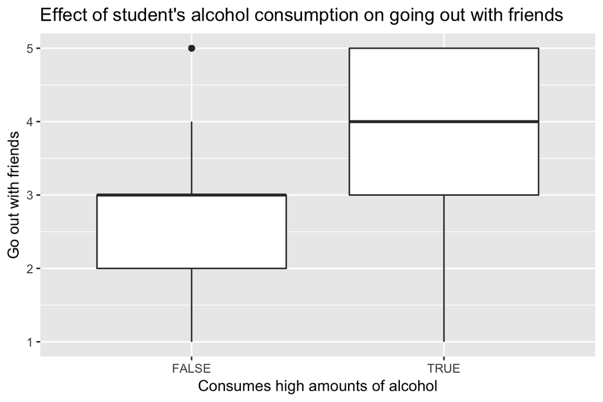

```r
g3<-ggplot(alc, aes(x=high_use, y=goout))
g3 + geom_boxplot() + ylab("Go out with friends")+xlab("Consumes high amounts of alcohol")+ggtitle("Effect of student's alcohol consumption on going out with friends")
```

Again it seems to have small logic, those who consume alcohol more, tend to spend more time out with their friends. So this time the TRUE group had higher points than the FALSE group (2.9 vs 3.7).

In the **data table 5** there are the mean values of the times they have been absent from the class with the same groups as previously (TRUE or FALSE on high alcohol consumption).

**Boxplot 4.** An effect of student’s alcohol consumption on times of absence from school.

```r
#access to libraries tidyr, dplyr and ggplot2.
library(tidyr); library(dplyr); library(ggplot2)

# What is the going out with friends in high/low consumer's group?
alc %>% group_by(high_use) %>% summarise(mean_grade=mean(absences))
```

```
## # A tibble: 2 × 2
##   high_use mean_grade
##      <lgl>      <dbl>
## 1    FALSE   3.705224
## 2     TRUE   6.368421
```

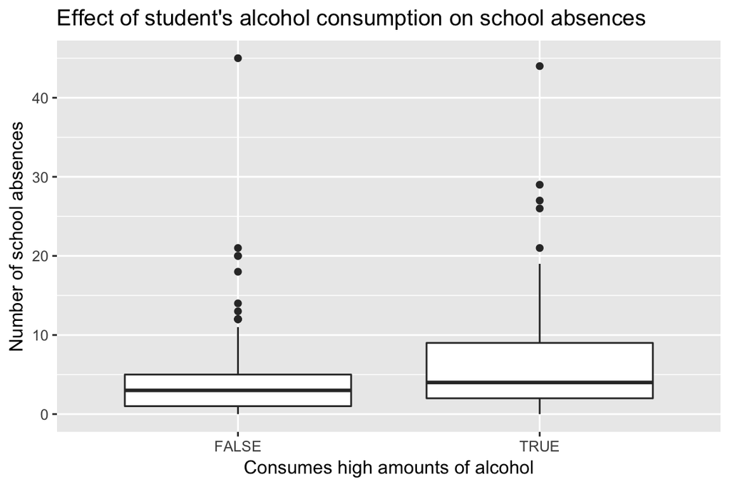

```r
g4<-ggplot(alc, aes(x=high_use, y=absences))
g4 + geom_boxplot() + ylab("Number of school absences")+xlab("Consumes high amounts of alcohol")+ggtitle("Effect of student's alcohol consumption on school absences")
```

Then the the relationships between the chosen variables and binary high/low alcohol consumption is explored statistically by logistic regression.

**Table 6.** The summary of fitted model and **Table 7.** the coefficients of the model.

```r
m<-glm(high_use~famrel+studytime+goout+absences, data=alc, family="binomial")
summary(m)
```

```
##
## Call:
## glm(formula = high_use ~ famrel + studytime + goout + absences,
##     family = "binomial", data = alc)
##
## Deviance Residuals:
##     Min       1Q   Median       3Q      Max
## -1.8701  -0.7738  -0.5019   0.8042   2.5416
##
## Coefficients:
##             Estimate Std. Error z value Pr(>|z|)
## (Intercept) -1.28606    0.70957  -1.812  0.06992 .
## famrel      -0.33699    0.13681  -2.463  0.01377 *
## studytime   -0.55089    0.16789  -3.281  0.00103 **
## goout        0.75953    0.12041   6.308 2.82e-10 ***
## absences     0.06753    0.02175   3.104  0.00191 **
## ---
## Signif. codes:  0 '***' 0.001 '**' 0.01 '*' 0.05 '.' 0.1 ' ' 1
##
## (Dispersion parameter for binomial family taken to be 1)
##
##     Null deviance: 465.68  on 381  degrees of freedom
## Residual deviance: 384.07  on 377  degrees of freedom
## AIC: 394.07
##
## Number of Fisher Scoring iterations: 4
```

```r
coef(m)
```

```
## (Intercept)      famrel   studytime       goout    absences
## -1.28606058 -0.33699130 -0.55089391  0.75953025  0.06753071
```

Also the logistic regression and coefficients of the model backs up the previous analysis. Coefficients are positive with the last two variables (goout and absences) but negative with the first ones (famrel) and (studytime).

Next the oddsratios and confidential intervals for the model are computed (**Table 8**).

```r
#compute oddratios and confidential intervals
OR<-coef(m)%>%exp
CI<-confint(m)%>%exp
#Print these out together
cbind(OR,CI)
```

```
##                    OR      2.5 %    97.5 %
## (Intercept) 0.2763573 0.06723596 1.0961732
## famrel      0.7139151 0.54460646 0.9331198
## studytime   0.5764343 0.41040872 0.7941804
## goout       2.1372720 1.69853389 2.7261579
## absences    1.0698631 1.02591583 1.1187950
```

Finally we are testing the predictive power of the model by 2x2 cross tabulation of predictions versus the actual values and predictions.

```r
#predict the probability of high_use
probabilities<-predict(m, type="response")

#add the predicted probabilities to alc
alc<-mutate(alc, probability=probabilities)

#use the probabilities to make a prediction of high use
alc<-mutate(alc, prediction=probability>0.5)

#Tabulate the target variable vs the predictions
table(high_use=alc$high_use, prediction=alc$prediction)
```

```
##         prediction
## high_use FALSE TRUE
##    FALSE   242   26
##    TRUE     65   49
```

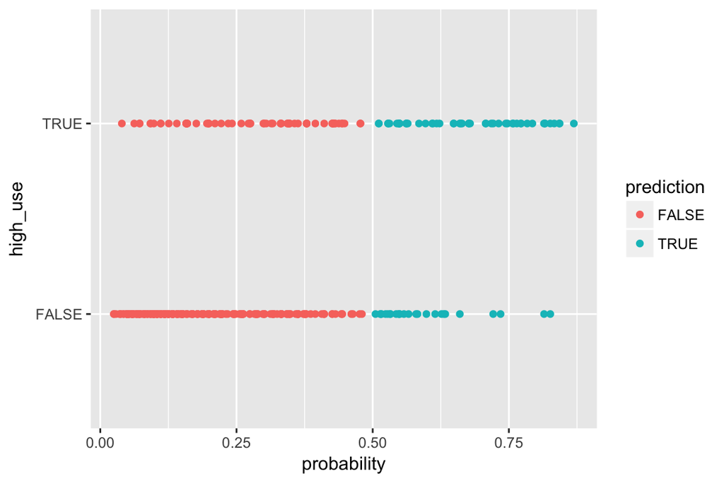

```r
#Initialize a plot of high use vs probability in alc
g<-ggplot(alc, aes(x=probability, y=high_use, col=prediction))

#Define the geom as point and draw the plot
g+geom_point()
```

```r
#Tabulate the target variable vs the predictions
table(high_use=alc$high_use, prediction=alc$prediction)%>% prop.table()%>%addmargins()
```

```
##         prediction
## high_use      FALSE       TRUE        Sum
##    FALSE 0.63350785 0.06806283 0.70157068
##    TRUE  0.17015707 0.12827225 0.29842932
##    Sum   0.80366492 0.19633508 1.00000000
```

Lastly, the total proportion of of inaccurately classified individuals (= the training error) is presented in the table below.

```r
#define mean prediction error
loss_func<-function(class, prob){
  n_wrong<-abs(class-prob)>0.5
  mean(n_wrong)
}
#Call loss_func to cumpute the average number of wrong predictions
loss_func(class=alc$high_use, prob=alc$probability)
```

```
## [1] 0.2382199
```